# TP2 Data mining LY Fadoum Ousmane

# Analyse du microbiote fécal d’un modèle de souris transgénique

## Description du modèle

Depuis plusieurs années, l’unité INSERM U1193 travaille sur le microbiote intestinal et ses relations avec l’hôte. Il dispose d’un modèle de souris transgénique qui exprime au niveau hépatique la protéine REG3A humaine et qui arbore un grand nombre de phénotypes particuliers. **Un premier travail a montré que l’expression de REG3A modifie la composition qualitative du microbiote intestinal chez ces souris et conduit à la résistance à la colite intestinale induite chimiquement.** (Darnaud*, Dos Santos* *et al.* Gastroenterology 2018).

**Vous allez reprendre cette étude à partir de nouvelles souris transgéniques pour REG3A et identifier le profil microbien différentiel.**

## Matériels et méthodes

**Entre 8 et 13 semaines de vie**, les souris ont été pesées et des fèces ont été récoltés puis congelés à -80°C.

L’ADN a été extrait, dosé et un séquençage métagénomique 16S a été réalisé dans le service de Biochimie de l’hôpital Paul Brousse.

Les séquences FASTQ ont ensuite été traités par le *workflow* **FROGS** développé par l’INRAE afin d’établir une table de comptage d’OTUs (*Operational Taxonomic Unit*) bactériens par échantillons.

Enfin la table d’OTU a été ré-échantillonner pour que tous les échantillons aient la même taille en nombre de séquences afin d’être comparés entre eux.

*Vous disposez d’une table de comptage des OTU regroupés en phylum (proportion en pourcentage) et d’un fichier simplifié de caractéristiques des souris utilisés pour l’étude*.

**!!! Attention, ces tableaux ont été générés par un étudiant en thèse (médecin de formation) pas très fortiche en tableau et en analyse de données… Vérifiez bien vos tableaux avant d’y travailler dessus !!!**

*Chargement des librairies*

```r
library(factoextra)
library(FactoMineR)
```

```r
library(ggplot2)
library(dplyr)
library(tidyr)
library(mvoutlier)
library(ggfortify)
```

*Import des données et quelques transformations pour l’exploitation des données*

```r
table_de_comptage<- read.csv("table_comptage_phylum.csv", sep=";")
caracteristiques<-read.csv("caracteristiques_souris.csv")

#Transformation des virgules en points dans la colonne du poids(poids_T0) et de l'age (age_T0) car sinon R ne les considère pas comme des valeurs numeriques
caracteristiques$poids_T0<-as.numeric(gsub(",", ".", caracteristiques$poids_T0))
caracteristiques$age_T0<-as.numeric(gsub(",", ".", caracteristiques$age_T0))

#Modification en facteurs pour afficher les différents niveaux des variables qualitatives
caracteristiques$sexe<-as.factor(caracteristiques$sexe)
caracteristiques$cage<-as.factor(caracteristiques$cage)
caracteristiques$Geno<-as.factor(caracteristiques$Geno)
```

## Résultats

### Description des souris

*Décrire les souris selon les variables descriptives et identifier des différences si il en existe.*

Les souris sont caractérisées par les variables descriptives suivantes: le génotype (*geno*), le sexe (*sexe*), l’âge au moment du prélèvement (*age_T0*), le poids au moment du prélèvement (*poids_T0*) et l’identification de la cage où elles ont été hébergées (*cage*).

```r
summary(caracteristiques)
```

```
##      souris         age_T0       sexe        cage      poids_T0     Geno
##  Min.   :1212   Min.   : 8.571   F:18   1      :6   Min.   :13.50   TG:19
##  1st Qu.:1246   1st Qu.:10.143   M:17   2      :6   1st Qu.:17.90   WT:16
##  Median :1254   Median :11.000          3      :5   Median :20.20
##  Mean   :1284   Mean   :10.935          9      :5   Mean   :21.53
##  3rd Qu.:1360   3rd Qu.:11.000          7      :3   3rd Qu.:25.95
##  Max.   :1373   Max.   :13.000          4      :2   Max.   :31.60
##                                         (Other):8
```

Globalement, on peut constater comme indiqué dans le materiel et methode, que les souris ont une tranche d’age située entre 8 et 13 semaines.

*Comparaison des souris sauvages WT et TG selon les variables descriptives*

```r
WT<-subset(caracteristiques, caracteristiques$Geno=="WT")
summary(WT)
```

```
##      souris         age_T0       sexe        cage      poids_T0     Geno
##  Min.   :1212   Min.   : 8.571   F:10   9      :5   Min.   :13.50   TG: 0
##  1st Qu.:1220   1st Qu.:10.143   M: 6   7      :3   1st Qu.:15.65   WT:16
##  Median :1362   Median :10.143          5      :2   Median :17.75
##  Mean   :1311   Mean   :10.920          8      :2   Mean   :18.84
##  3rd Qu.:1369   3rd Qu.:13.000          11     :2   3rd Qu.:20.75
##  Max.   :1373   Max.   :13.000          6      :1   Max.   :28.00
##                                         (Other):1
```

```r
TG<-subset(caracteristiques, caracteristiques$Geno=="TG")
summary(TG)
```

```
##      souris         age_T0      sexe        cage      poids_T0     Geno
##  Min.   :1243   Min.   :10.86   F: 8   1      :6   Min.   :17.90   TG:19
##  1st Qu.:1248   1st Qu.:10.86   M:11   2      :6   1st Qu.:19.75   WT: 0
##  Median :1252   Median :11.00          3      :5   Median :25.00
##  Mean   :1261   Mean   :10.95          4      :2   Mean   :23.81
##  3rd Qu.:1280   3rd Qu.:11.00          5      :0   3rd Qu.:26.35
##  Max.   :1285   Max.   :11.00          6      :0   Max.   :31.60
##                                        (Other):0
```

Le tableau ci-dessus permet de constater qu’on a 16 souris sauvages (WT) dont 10 femelles et 6 males. Les souris transgéniques sont au nombre de 19; soient 8 femelles et 11 males. Il nous offre par ailleurs un apercu des ages ainsi que des poids des deux catégories de souris lors du prélèvement. En effet, on peut observer que chez les WT, l’age minimale est de 8 semaines et celle maximale est de 13 semaines.

Chez les souris transgéniques(TG), l’age est située entre 10 et 11 semaines. Il semble y avoir une différence de poids entre les deux catégories de souris. Pour élucider cela, observons la distribution des poids chez les deux types de souris. Afin de signifier l’existence de différence, des tests statistiques selon également réalisés.

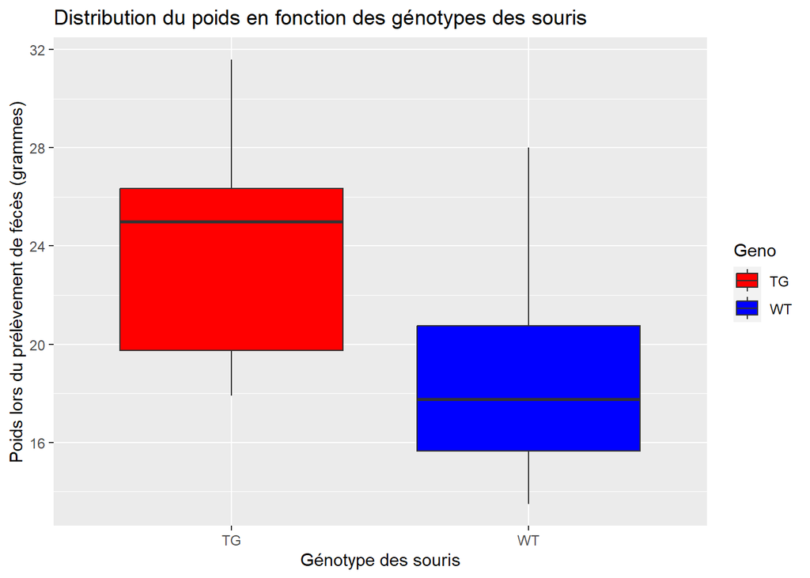

```r
ggplot(caracteristiques, aes(x = Geno, y = poids_T0, fill = Geno)) +
  geom_boxplot() +
  scale_fill_manual(values = c("red", "blue")) +
  labs(title = "Distribution du poids en fonction des génotypes des souris", x = "Génotype des souris", y = "Poids lors du prélèvement de fécès (grammes)")
```

*Test de comparaison des poids moyens des souris sauvages et transgéniques (t.test)*

La réalisation du test de comparaison de moyenne (t.test) requiert la normalité des données de chaque groupe ainsi que l’homogénéité des variances. Procédons à la vérification de ces deux conditions.

1. *Normalité des données: Test de normalité de shapiro-wilk*

```r
#HO: Les données suivent une loi normale
#H1: Inverse
shapiro.test(WT$poids_T0)
```

```
##
##  Shapiro-Wilk normality test
##
## data:  WT$poids_T0
## W = 0.89884, p-value = 0.07701
```

```r
shapiro.test(TG$poids_T0)
```

```
##
##  Shapiro-Wilk normality test
##
## data:  TG$poids_T0
## W = 0.90997, p-value = 0.07393
```

Conclusion: Les données de poids des deux goupes (WT et TG) suivent une loi normale (p-value=0.07701(WT); p-value=0.07393(TG) >0,05).

2. *Homogénéité des variances des poids des deux types de souris: var.test*

```r
#Ho: Les variances des deux groupes sont égales
#H1: Inverse
var.test(data=caracteristiques,poids_T0~Geno)
```

```
##
##  F test to compare two variances
##
## data:  poids_T0 by Geno
## F = 0.92103, num df = 18, denom df = 15, p-value = 0.8578
## alternative hypothesis: true ratio of variances is not equal to 1
## 95 percent confidence interval:
##  0.3298927 2.4561283
## sample estimates:
## ratio of variances
##          0.9210301
```

Conclusion: Les variances des poids des deux groupes de souris (WT et TG) sont égales (p-value = 0.8578 > 0,05).

3. *Test de comparaison des poids moyens des deux goupes de souris sauvages (WT) et transgéniques (TG): test t*

```r
#Ho : Les moyennes des deux groupes sont égales
#H1: Les moyennes ne sont pas égales
t.test(data=caracteristiques,poids_T0~Geno)
```

```
##
##  Welch Two Sample t-test
##
## data:  poids_T0 by Geno
## t = 3.4076, df = 31.5, p-value = 0.00181
## alternative hypothesis: true difference in means between group TG and group WT is not equal to 0
## 95 percent confidence interval:
##  1.996334 7.939192
## sample estimates:
## mean in group TG mean in group WT
##         23.80526         18.83750
```

```r
#Calculs des poids moyens
mean(WT$poids_T0)
```

```
## [1] 18.8375
```

```r
mean(TG$poids_T0)
```

```
## [1] 23.80526
```

Conclusion: Le poids moyen des souris transgéniques (23.80526 g; TG) est significativement plus élevé (Welch Two Sample t-test, p-value = 0.00181) que celui des souris sauvages (18.8375g ; WT ).

La modification génétique permettant l’expression de la protéine REG3A dans le foie semble conférer un avantage phénotypique aux souris transgéniques par rapport aux souris sauvages. En ce sens, pour mieux élucider les différences entre ces deux groupes de souris, étudions plus en détail la composition en phyla de leur microbiote intestinal.

*Répartition des WT et TG dans les cages*

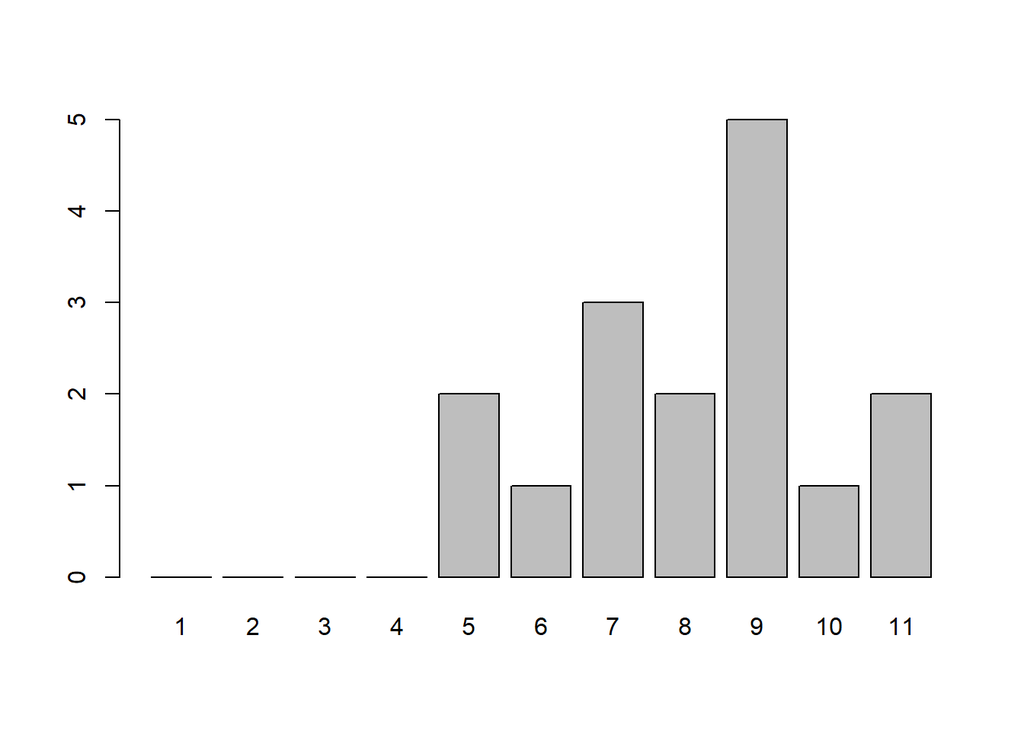

```r
plot(WT$cage)
```

Nous pouvons constater que les souris sauvages (WT) sont réparties dans les cages: 5, 6, 7, 8, 9, 10 et 11.

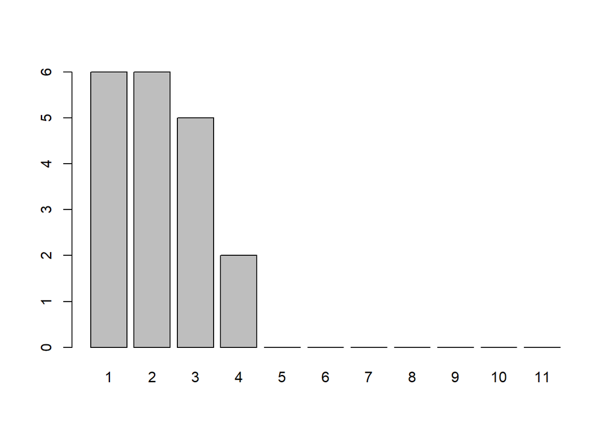

```r
plot(TG$cage)
```

Les souris transgéniques quant à elles sont réparties dans des cages différentes de celles WT. En effet, elles sont réparties dans les cages 1, 2 3 et 4.

### Description des variables bactériennes (uni-varié)

*Fusion du tableau contenant les différents phyla avec celui des caractéristiques pour associer chaque souris à sa composition en phyla et pouvoir ainsi classifier les WT et les TG*

```r
#Transformation des colonnes en lignes et inversement
comptage_transposed <- t(table_de_comptage)

#Suppression de la première ligne
comptage_transposed  <- comptage_transposed[-1,]

#Renommer les colonnes
colonnes <- c("Bacteroidetes","Actinobacteria","Tenericutes","Verrucomicrobia","Cyanobacteria","Firmicutes","Proteobacteria","Patescibacteria","Deferribacteres")
colnames(comptage_transposed)<- colonnes

#Suppression de la ligne 33 car cette souris est absente dans la table de comptage
caracteristiques_corrigé <- caracteristiques [-33, ]

#Fusion des deux tableaux corrigés
tableau_fusionnée<- cbind (caracteristiques_corrigé,comptage_transposed)
```

- *Distribution, moyenne et ecart-type des phyla identifiés par genotype.*

*Distribution des phyla: Boxplot*

```r
head(tableau_fusionnée)
```

|  | souris | age_T0 | sexe | cage | poids_T0 | Geno | Bacteroidetes | Actinobacteria | Tenericutes | Verrucomicrobia | Cyanobacteria | Firmicutes | Proteobacteria | Patescibacteria | Deferribacteres |
| --- | --- | --- | --- | --- | --- | --- | --- | --- | --- | --- | --- | --- | --- | --- | --- |
| 1 | 1212 | 13 | M | 5 | 27.0 | WT | 78.405941692 | 0.292967204 | 0.001583607 | 0.014252459 | 0.261295073 | 20.037373114 | 0.908990134 | 0.038006556 | 0.039590163 |
| 2 | 1213 | 13 | M | 5 | 28.0 | WT | 67.53289943 | 0.28346556 | 0.00000000 | 0.03325574 | 0.60335408 | 29.24604494 | 1.22254422 | 0.89157046 | 0.18686557 |
| 3 | 1218 | 13 | M | 6 | 24.3 | WT | 62.5777947 | 0.2296229 | 0.0000000 | 0.0253377 | 0.2707967 | 35.3904382 | 0.6271082 | 0.6777836 | 0.2011180 |
| 4 | 1219 | 13 | F | 7 | 18.5 | WT | 73.308312351 | 0.267629499 | 0.000000000 | 0.007918033 | 0.975501607 | 23.781018892 | 1.152865536 | 0.467163919 | 0.039590163 |
| 5 | 1220 | 13 | F | 7 | 17.9 | WT | 59.47234231 | 0.37531474 | 0.00000000 | 0.02850492 | 0.25179343 | 36.14898570 | 2.53852123 | 0.13777377 | 1.04676390 |
| 6 | 1221 | 13 | F | 7 | 17.6 | WT | 57.127021078 | 0.253377041 | 0.001583607 | 0.031672130 | 0.313554088 | 41.010657672 | 0.552678670 | 0.343642612 | 0.365813103 |

[figure not shown]

```r
donnees <- data.frame(
  Geno = rep(c("WT", "TG"), each = 50),
   Bacteroidetes= rnorm(100),
  Actinobacteria = rnorm(100),
  Tenericutes = rnorm(100),
  Verrucomicrobia = rnorm(100),
  Cyanobacteria = rnorm(100),
  Firmicutes = rnorm(100),
  Proteobacteria = rnorm(100),
  Patescibacteria = rnorm(100),
  Deferribacteres=rnorm(100)
)

# Mise des données dans un format long pour ggplot2
donnees_long <- tidyr::gather(donnees, key = "Phylum", value = "Quantite", -Geno)

# Réalisation du boxplot
ggplot(donnees_long, aes(x = Phylum, y = Quantite, fill = Geno)) +
  geom_boxplot() +
  labs(title = "Boxplots des différents phyla en fonction des types de souris(WT et TG)",
       x = "Phylum",
       y = "Quantité") +
  theme_minimal() +
  theme(axis.text.x = element_text(angle = 45, hjust = 1))
```

Une conversion en valeurs numériques des proportions des différents phyla est effectuée avec remplacement des virgules en points.

```r
# Conversion de chaque colonne individuellement
tableau_fusionnée$Bacteroidetes <- as.numeric(gsub(",", ".", tableau_fusionnée$Bacteroidetes))
tableau_fusionnée$Actinobacteria <- as.numeric(gsub(",", ".", tableau_fusionnée$Actinobacteria))
tableau_fusionnée$Tenericutes <- as.numeric(gsub(",", ".", tableau_fusionnée$Tenericutes))
tableau_fusionnée$Verrucomicrobia <- as.numeric(gsub(",", ".", tableau_fusionnée$Verrucomicrobia))
tableau_fusionnée$Cyanobacteria <- as.numeric(gsub(",", ".", tableau_fusionnée$Cyanobacteria))
tableau_fusionnée$Firmicutes <- as.numeric(gsub(",", ".", tableau_fusionnée$Firmicutes))
tableau_fusionnée$Proteobacteria <- as.numeric(gsub(",", ".", tableau_fusionnée$Proteobacteria))
tableau_fusionnée$Patescibacteria <- as.numeric(gsub(",", ".", tableau_fusionnée$Patescibacteria))
tableau_fusionnée$Deferribacteres<- as.numeric(gsub(",", ".", tableau_fusionnée$Deferribacteres))

# Vérification des modifications
head(tableau_fusionnée)
```

|  | souris | age_T0 | sexe | cage | poids_T0 | Geno | Bacteroidetes | Actinobacteria | Tenericutes | Verrucomicrobia | Cyanobacteria | Firmicutes | Proteobacteria | Patescibacteria | Deferribacteres |
| --- | --- | --- | --- | --- | --- | --- | --- | --- | --- | --- | --- | --- | --- | --- | --- |
| 1 | 1212 | 13 | M | 5 | 27.0 | WT | 78.40594 | 0.2929672 | 0.001583607 | 0.014252459 | 0.2612951 | 20.03737 | 0.9089901 | 0.03800656 | 0.03959016 |
| 2 | 1213 | 13 | M | 5 | 28.0 | WT | 67.53290 | 0.2834656 | 0.000000000 | 0.033255740 | 0.6033541 | 29.24604 | 1.2225442 | 0.89157046 | 0.18686557 |
| 3 | 1218 | 13 | M | 6 | 24.3 | WT | 62.57779 | 0.2296229 | 0.000000000 | 0.025337700 | 0.2707967 | 35.39044 | 0.6271082 | 0.67778360 | 0.20111800 |
| 4 | 1219 | 13 | F | 7 | 18.5 | WT | 73.30831 | 0.2676295 | 0.000000000 | 0.007918033 | 0.9755016 | 23.78102 | 1.1528655 | 0.46716392 | 0.03959016 |
| 5 | 1220 | 13 | F | 7 | 17.9 | WT | 59.47234 | 0.3753147 | 0.000000000 | 0.028504920 | 0.2517934 | 36.14899 | 2.5385212 | 0.13777377 | 1.04676390 |
| 6 | 1221 | 13 | F | 7 | 17.6 | WT | 57.12702 | 0.2533770 | 0.001583607 | 0.031672130 | 0.3135541 | 41.01066 | 0.5526787 | 0.34364261 | 0.36581310 |

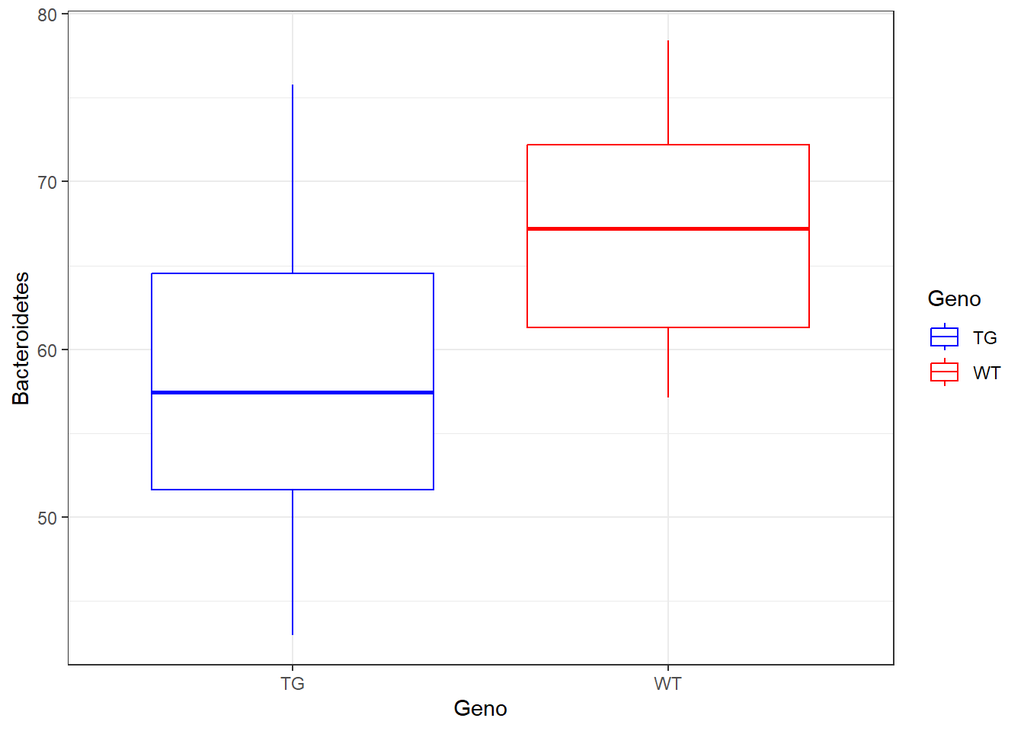

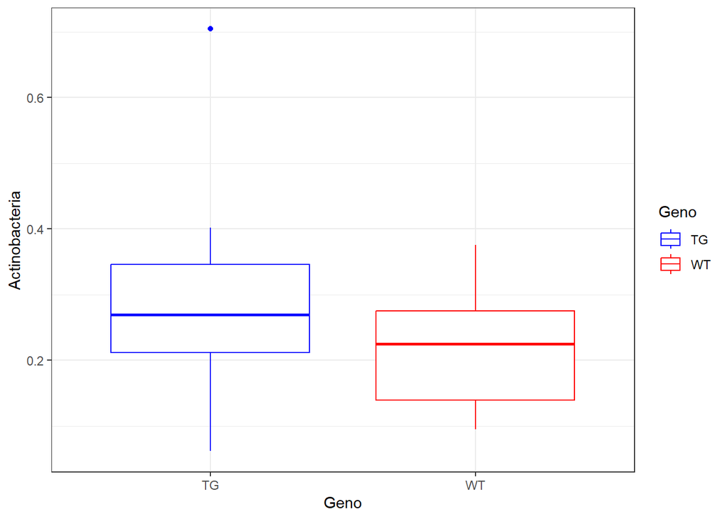

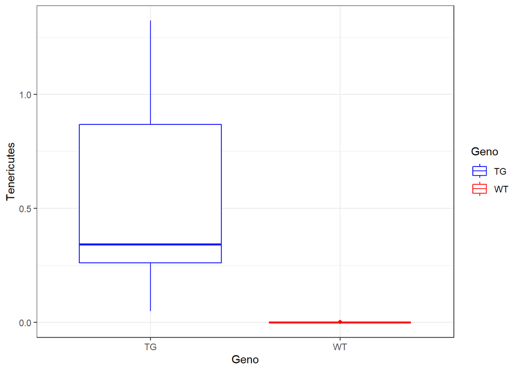

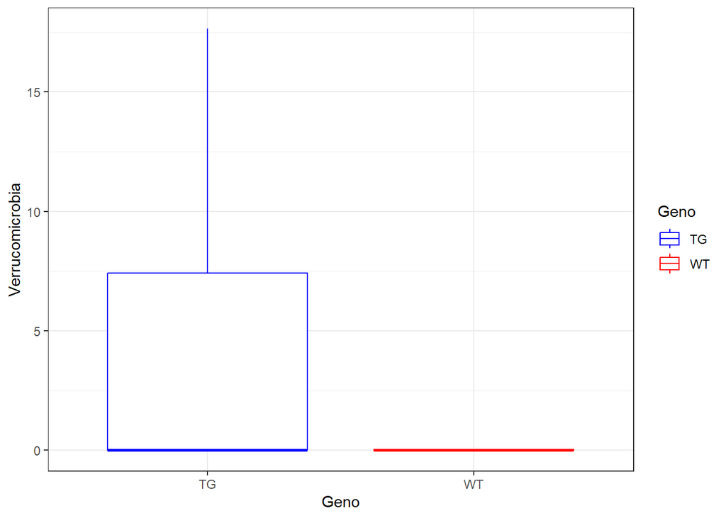

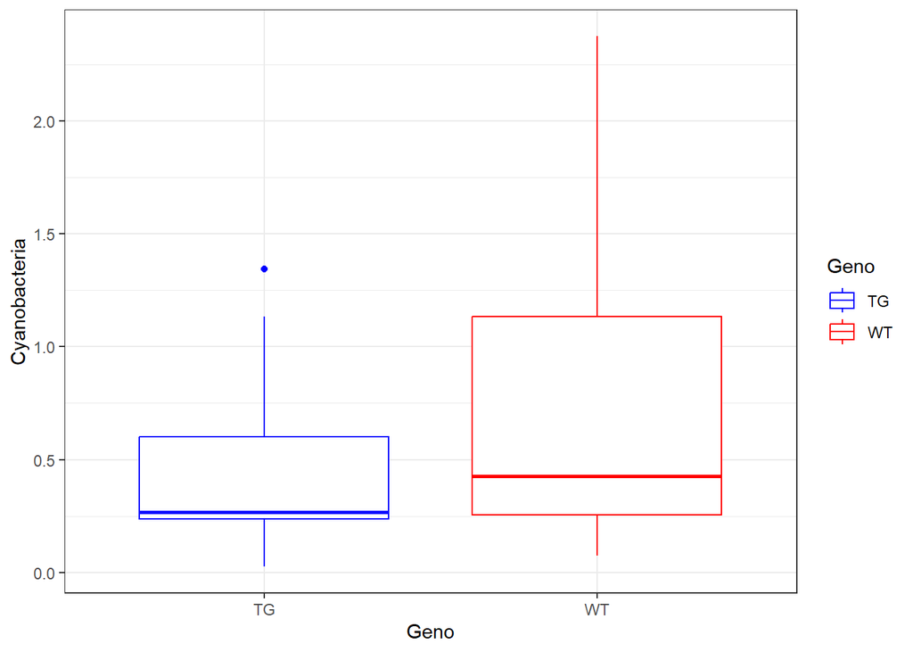

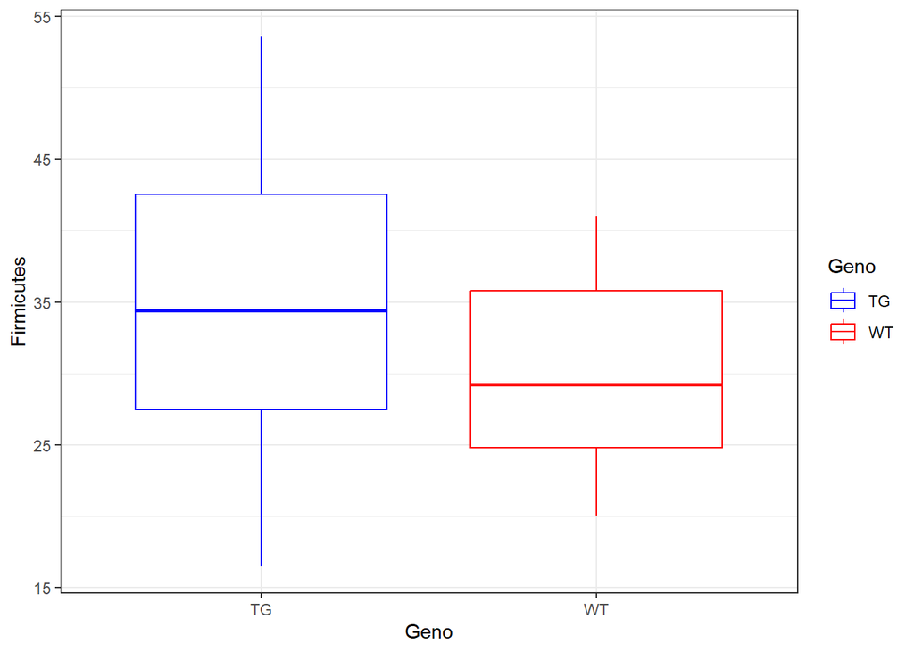

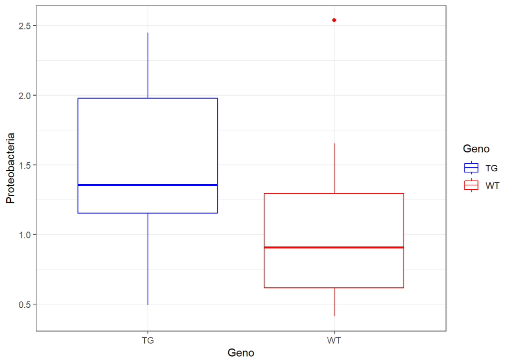

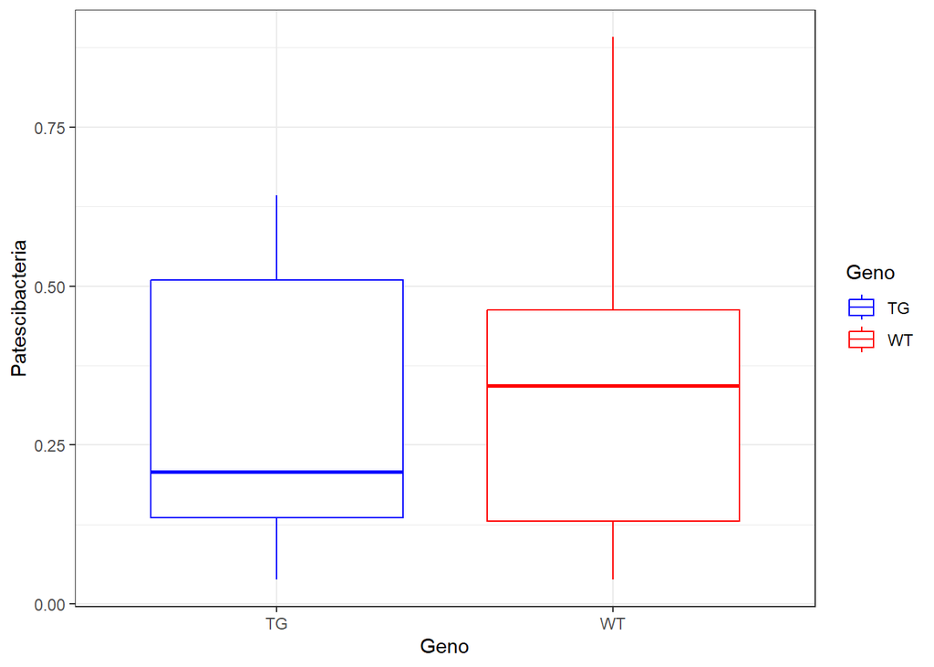

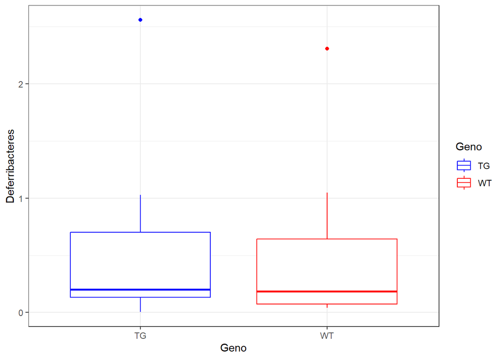

```r
#Extraction des données de phylas selon les génotypes uniquement à partir de la colonne 6
new_tableau <- subset(tableau_fusionnée, select = -c(1:5))

#Accès au noms des colonnes du tableau new_tableau
col_names <- colnames(new_tableau)

#Ajout de couleurs en fonction du génotype
color_vector <- c("red", "blue")

for (col_name in colnames(new_tableau)[-1]) {
  p <- ggplot(new_tableau, aes(x = Geno, y = .data[[col_name]], color = Geno)) +
    geom_boxplot() +
    theme_bw() +
    labs(x = "Geno", y = col_name) +
    scale_color_manual(values = setNames(color_vector, unique(new_tableau$Geno)))

  print(p)
}
```

Cependant, la distribution des phyla restent variables selon les génotypes. Par exemple, les Firmicutes et Proteobacteria seraient plus importants chez les TG que chez les WT. A l’inverse, les proportions de Cyanobacteria et des Bacteroidetes semblent etre plus élevées chez les WT que chez les TG.

- *Moyenne et ecart-type des phyla identifiés par genotype*

*Phyla moyens identifié par génotype*

```r
aggregate(.~Geno,data=new_tableau,mean) #aggregate permet de rassembler les données par génotype
```

| Geno | Bacteroidetes | Actinobacteria | Tenericutes | Verrucomicrobia | Cyanobacteria | Firmicutes | Proteobacteria | Patescibacteria | Deferribacteres |
| --- | --- | --- | --- | --- | --- | --- | --- | --- | --- |
| TG | 57.86006 | 0.2846324 | 0.5575961906 | 3.63829427 | 0.4312411 | 34.94886 | 1.517512 | 0.2835489 | 0.4782492 |
| WT | 67.10057 | 0.2105141 | 0.0002111476 | 0.01171869 | 0.7774452 | 30.06224 | 1.050142 | 0.3374138 | 0.4497442 |

*Ecart-type des phyla identifiés par genotype*

```r
aggregate(.~Geno,data=new_tableau,sd)
```

| Geno | Bacteroidetes | Actinobacteria | Tenericutes | Verrucomicrobia | Cyanobacteria | Firmicutes | Proteobacteria | Patescibacteria | Deferribacteres |
| --- | --- | --- | --- | --- | --- | --- | --- | --- | --- |
| TG | 8.957705 | 0.13873297 | 0.4043419767 | 5.95866219 | 0.3667006 | 10.326225 | 0.5361079 | 0.2023842 | 0.5940054 |
| WT | 6.792157 | 0.08580849 | 0.0005572171 | 0.01202767 | 0.7731662 | 6.492902 | 0.5588272 | 0.2649465 | 0.6279594 |

- *Identifier les phyla majoritaires*

```r
# Calcul des statistiques descriptives par génotype
# Calcul de la moyenne et de l'écart-type par génotype
data_by_geno <- new_tableau %>%  group_by(Geno) %>%  summarise(across(c(Bacteroidetes, Actinobacteria, Tenericutes, Verrucomicrobia, Cyanobacteria, Firmicutes, Proteobacteria, Patescibacteria, Deferribacteres), list(sum = ~sum(.x, na.rm = TRUE))))

print(data_by_geno)
```

```
## # A tibble: 2 × 10
##   Geno  Bacteroidetes_sum Actinobacteria_sum Tenericutes_sum Verrucomicrobia_sum
##   <fct>             <dbl>              <dbl>           <dbl>               <dbl>
## 1 TG                1099.               5.41        10.6                  69.1
## 2 WT                1007.               3.16         0.00317               0.176
## # ℹ 5 more variables: Cyanobacteria_sum <dbl>, Firmicutes_sum <dbl>,
## #   Proteobacteria_sum <dbl>, Patescibacteria_sum <dbl>,
## #   Deferribacteres_sum <dbl>
```

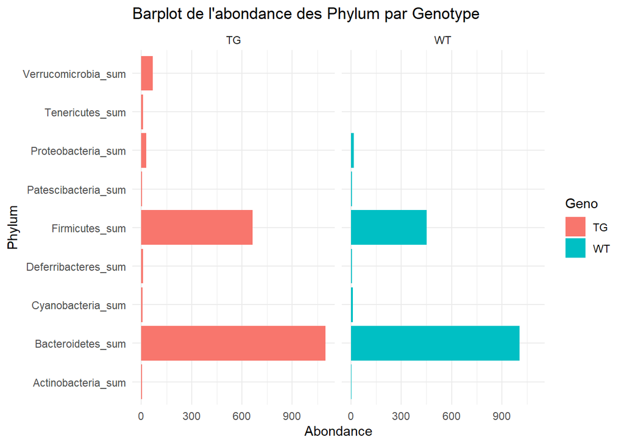

```r
# Pivot pour que ggplot puisse l'utiliser correctement.
data_by_geno_long <- pivot_longer(  data_by_geno,   cols = -Geno,   names_to = "Phylum",   values_to = "Abundance")

# Création d'un Barplot avec les données pivotées
ggplot(data_by_geno_long, aes(x = Phylum,y = Abundance, fill= Geno)) +  coord_flip()+  geom_bar(stat = "identity", position = "dodge") +  facet_wrap(~ Geno) +  labs(title = "Barplot de l'abondance des Phylum par Genotype",y="Abondance")+   theme_minimal()
```

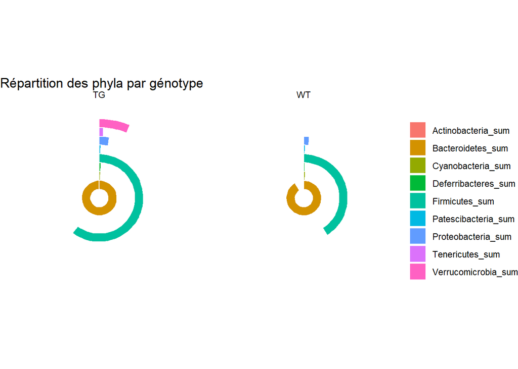

```r
# Créer un camembert pour chaque génotype
ggplot(data_by_geno_long, aes(x = Phylum, y = Abundance, fill = Phylum)) +  geom_bar(width = 1, stat = "identity", color = "white") +  coord_polar("y", start = 0) +  facet_wrap(~ Geno) +
  labs(title = "Répartition des phyla par génotype", x = NULL, y = NULL) +  theme_void() +
 theme(legend.title = element_blank()) +
scale_fill_discrete(name = "Phylum")
```

### Analyse factorielle

Nous avons recouru à une analyse factorielle dans le but d’étudier les individus en fonction des bactéries présentes.

- *Quel analyse allez-vous utiliser ? Argumentez votre choix*

On réalise une analyse ACP (Analyse en composante principale) car on a plus de deux variables quantitatives; les différents phyla représentant les variables quantitatives.

*Réalisation de l’ACP*

```r
#new_tableau_acp contient les données des différentes phyla et le génotype
new_tableau_acp <- subset(tableau_fusionnée, select = -c(2:5))
acp_phyla<-PCA(new_tableau_acp, quali.sup = c(1:2), scale.unit=1, graph=F)
```

*Choix des composantes*

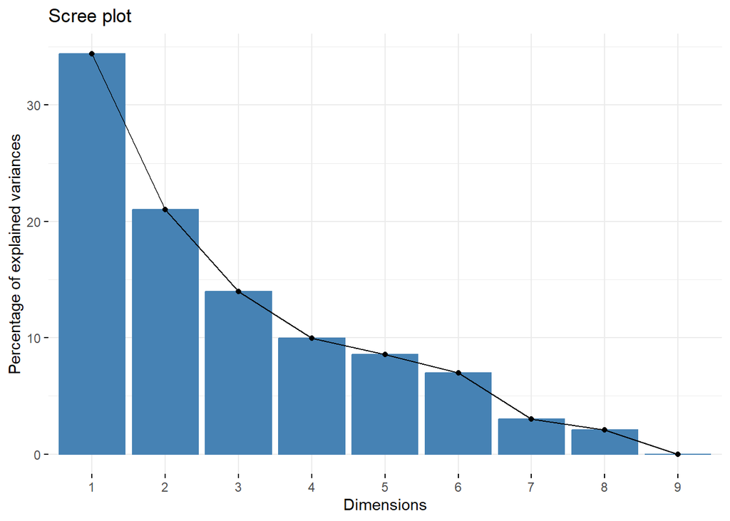

```r
fviz_screeplot(acp_phyla)
```

Regardons les valeurs propres.

```r
acp_phyla$eig
```

```
##          eigenvalue percentage of variance cumulative percentage of variance
## comp 1 3.097777e+00           3.441975e+01                          34.41975
## comp 2 1.891883e+00           2.102092e+01                          55.44067
## comp 3 1.256259e+00           1.395843e+01                          69.39910
## comp 4 8.981991e-01           9.979990e+00                          79.37909
## comp 5 7.698564e-01           8.553960e+00                          87.93305
## comp 6 6.290693e-01           6.989659e+00                          94.92271
## comp 7 2.698368e-01           2.998187e+00                          97.92090
## comp 8 1.871191e-01           2.079101e+00                         100.00000
## comp 9 5.517987e-18           6.131097e-17                         100.00000
```

Les trois premières composantes ont des valeurs propres supérieures à 1. Cependant, comme on ne peut travailler qu’avec deux composantes (2 dimensions), on choisit les deux premières composantes pour la suite de notre étude.

*Cercle de corrélation et graphe des individus*

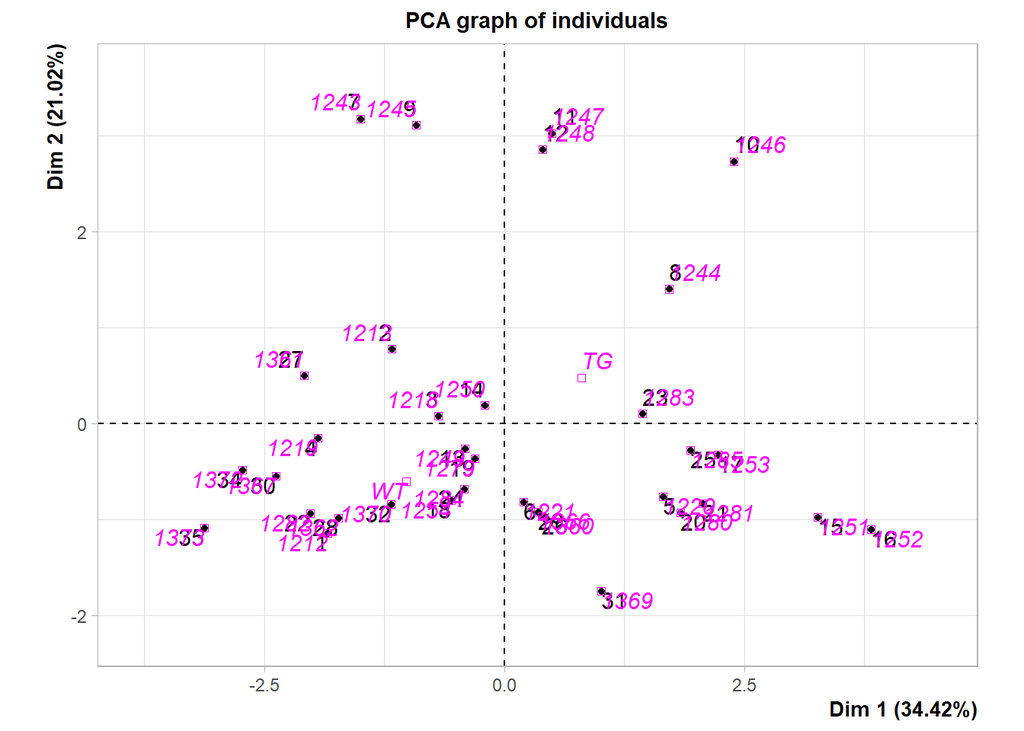

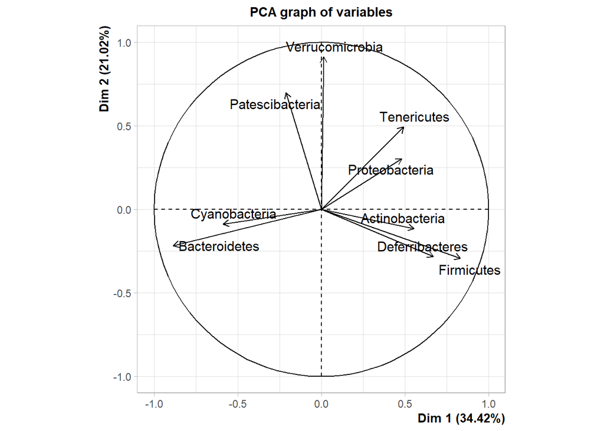

```r
acp_phyla<-PCA(new_tableau_acp, quali.sup = c(1:2), scale.unit=1, graph=T, ncp=2)
```

Les deux génotypes ne sont pas très bien identifiables sur le graphe des individus. On le refait de la façon suivante:

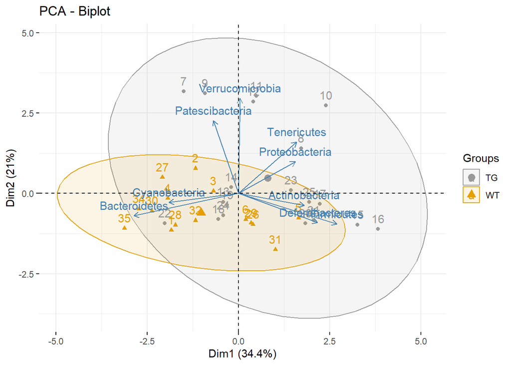

```r
fviz_pca_biplot (acp_phyla, habillage=factor(new_tableau_acp$Geno),
     addEllipses=T,
     palette = c("#999999", "#E69F00"))
```

*Rassemblement de la dispersion des individus selon le genre*

```r
head(tableau_fusionnée)
```

|  | souris | age_T0 | sexe | cage | poids_T0 | Geno | Bacteroidetes | Actinobacteria | Tenericutes | Verrucomicrobia | Cyanobacteria | Firmicutes | Proteobacteria | Patescibacteria | Deferribacteres |
| --- | --- | --- | --- | --- | --- | --- | --- | --- | --- | --- | --- | --- | --- | --- | --- |
| 1 | 1212 | 13 | M | 5 | 27.0 | WT | 78.40594 | 0.2929672 | 0.001583607 | 0.014252459 | 0.2612951 | 20.03737 | 0.9089901 | 0.03800656 | 0.03959016 |
| 2 | 1213 | 13 | M | 5 | 28.0 | WT | 67.53290 | 0.2834656 | 0.000000000 | 0.033255740 | 0.6033541 | 29.24604 | 1.2225442 | 0.89157046 | 0.18686557 |
| 3 | 1218 | 13 | M | 6 | 24.3 | WT | 62.57779 | 0.2296229 | 0.000000000 | 0.025337700 | 0.2707967 | 35.39044 | 0.6271082 | 0.67778360 | 0.20111800 |
| 4 | 1219 | 13 | F | 7 | 18.5 | WT | 73.30831 | 0.2676295 | 0.000000000 | 0.007918033 | 0.9755016 | 23.78102 | 1.1528655 | 0.46716392 | 0.03959016 |
| 5 | 1220 | 13 | F | 7 | 17.9 | WT | 59.47234 | 0.3753147 | 0.000000000 | 0.028504920 | 0.2517934 | 36.14899 | 2.5385212 | 0.13777377 | 1.04676390 |
| 6 | 1221 | 13 | F | 7 | 17.6 | WT | 57.12702 | 0.2533770 | 0.001583607 | 0.031672130 | 0.3135541 | 41.01066 | 0.5526787 | 0.34364261 | 0.36581310 |

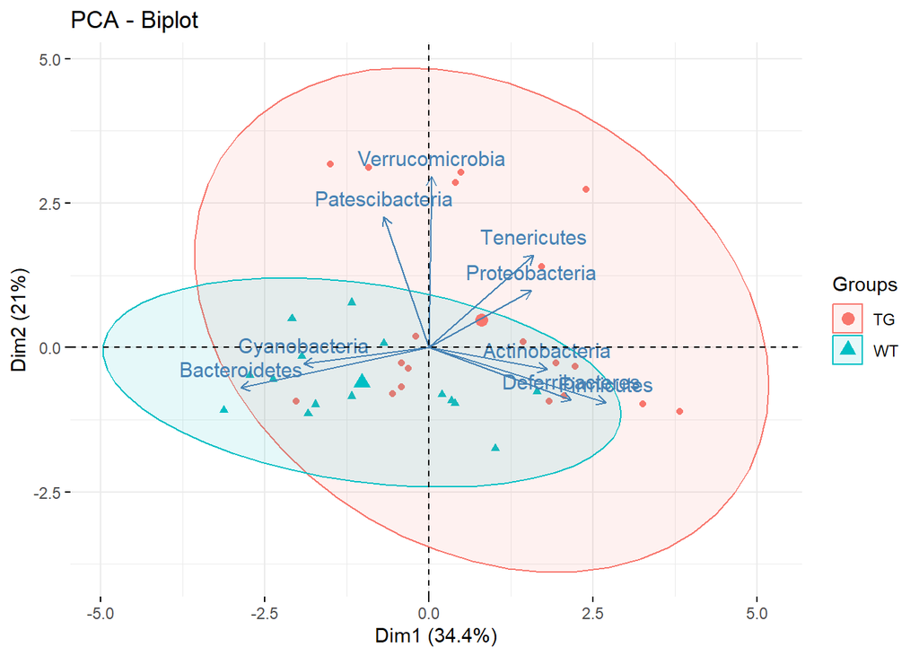

```r
fviz_pca_biplot(acp_phyla,geom="point",
             axes=c(1,2),
             habillage = tableau_fusionnée$Geno,
             addEllipses = T)
```

- *A l’aide des indices numériques et des graphiques obtenus, rédigez un paragraphe de commentaires sur l’étude des souris en fonction des phyla.*

Les différentes souris ont été regroupées selon le genre. Une superposition de la distribution des souris selon le génotype est observée. Ce qui signifie que les deux types de souris (WT et TG) partagent des phyla en commun; à savoir les Bacteroidetes, Cyanobacteria, Actinobacteria… Cependant, on constate que certaines souris transgéniques seulement seraient constituées des phyla Verrucomicrobia, Tenericutes et Proteobacteria.

- *Remarquez vous un groupe outlier chez les souris transgéniques. Si oui, expliquez comment êtes vous arrivés à cette conclusion, décrivez ce groupe par rapport aux deux autres et identifier une raison putative au décrochage de ce groupe.*

Le groupe outlier chez les souris transgéniques serait représenté par les souris se situant en haut sur le biplot PCA. Pour confirmer ou infirmer cela, réalisons l’analyse selon les différentes variables descriptives.

*Dispersion des souris transgéniques selon les cages*

```
## Too few points to calculate an ellipse
```

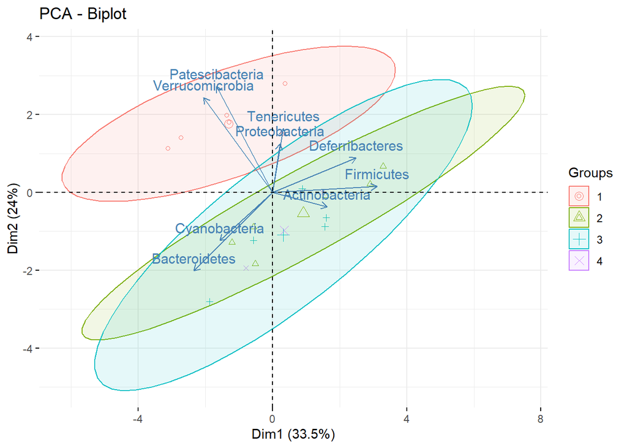

```r
#Subset des données de TG a partir du tableau fusionnée
TG <- subset(tableau_fusionnée, tableau_fusionnée$Geno=="TG")

acp_TG<-PCA(TG, graph=F, quali.sup = c(1:6))

fviz_pca_biplot(acp_TG,geom="point",
             axes=c(1,2),
             habillage = TG$cage,
             addEllipses = T)
```

En se basant sur les numéros de cages dans lesquelles les souris transgéniques ont été réparties, on distingue bien les 4 premières cages comme indiqué dans les données mises à notre disposition. Comme on a représenté que les souris transgéniques, on devrait avoir quasiment toutes les distributions selon le numéro de cage qui se superposent; ce qui n’est pas le cas. En effet, le groupe de souris de la cage 1, est complétement isolé des autres souris transgéniques. La forte présence du phyla Verrucomicrobia dans les fécès des souris transgéniques présentes uniquement dans la cage 1 pourrait s’expliquer par une infection bactérienne.

Les travaux de Zhu et al., 2017; Eckburg et al., 2005 mettent en exergue que le tractus gastro-intestinal abrite de nombreux phyla Bacteroidetes, Firmicutes, Actinomycetes, Proteobacteria et des Verrucomicrobia. Ces microorganismes communs ont des rôles vitaux dans la digestion des glucides non digérables, la production de vitamines, la fonction du système immunitaire et l’inflammation (Lyon, 2018). Ainsi, les Verrucomicrobia peuvent etre présents dans le tube digestif mais pas en grande quantité.

Par conséquent, d’après les travaux de Zhu et al., 2017, un changement de la diversité des micro-organismes perturbe l’équilibre micro-écologique et provoque ainsi un ensemble de déviations non biotiques pour l’hôte. Donc nous pouvons en déduire que le poids moyen plus élvé chez des souris transgéniques s’expliquerait par une perturbation de l’equilibre microbiotique intestinal suite à une infection qui a entrainné l’augmentation de Verrucomicrobia. Il serait tout de meme interessant de confirmer par un test statistique que les souris transgéniques de la cage 1 sont les seules à avoir un poids plus important.

Le groupe outlier est donc à exclure de notre analyse car il constitue un biais en ce qui concerne l’etude du microbiote différentiel des souris transgéniques.

*Dispersion des souris transgéniques selon le sexe*

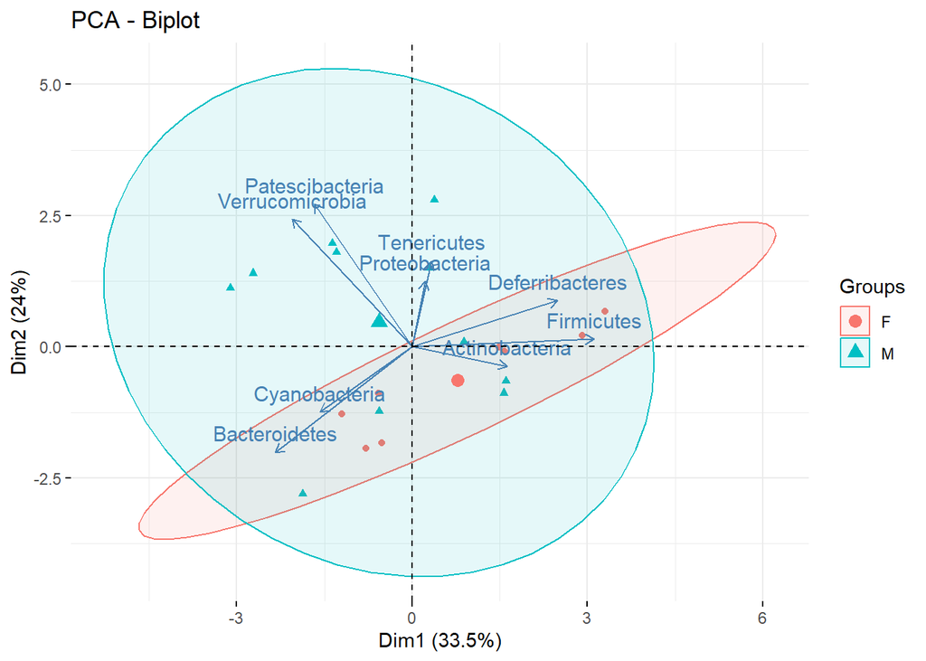

```r
#Subset des données de TG a partir du tableau fusionnée
TG <- subset(tableau_fusionnée, tableau_fusionnée$Geno=="TG")

acp_TG<-PCA(TG, graph=F, quali.sup = c(1:6))

fviz_pca_biplot(acp_TG,geom="point",
             axes=c(1,2),
             habillage = TG$sexe,
             addEllipses = T)
```

La dispersiondes souris transgéniques selon le sexe montre que le groupe outlier, étant constitué de souris de la cage 1, est constitué uniquement de males.

- *Pouvez vous identifier un phylum caractéristique de ce groupe. Montrez et commentez*

D’après les biplots ci-dessus montrant la dispersion des souris transgéniques selon les cages en fonction des dimensions 1 et 2, l’un des phyla caractéristique de ce groupe serait le phyla des Verrucomicrobia. Vérifions cela avec une représentaion graphique de la quantité de Verrucomicrobia.

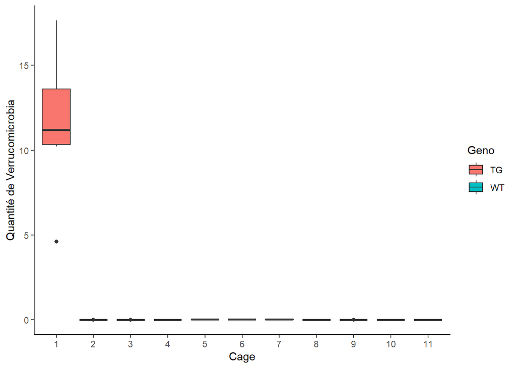

```r
ggplot(data = tableau_fusionnée, aes(x = cage, y = Verrucomicrobia, fill = Geno)) +
  geom_boxplot() +
  scale_x_discrete("Cage") +
  scale_y_continuous("Quantité de Verrucomicrobia") +
  theme_classic()
```

Le boxplot suivant permet de constater que les Verrumicrobia sont présents en grande quantité dans les fécès des souris transgéniques de la cage 1. Ce qui confirme l’hypothèse selon laquelle le groupe outlier est représenté par les souris de la cage 1.

- *Re-analyser via l’analyse factorielle les deux groupes de souris restants et identifier les phyla différents entre les groupes*

*Re-analyse des deux groupes de souris restants*

Pour ce faire, on supprime les souris transgéniques de la cage.

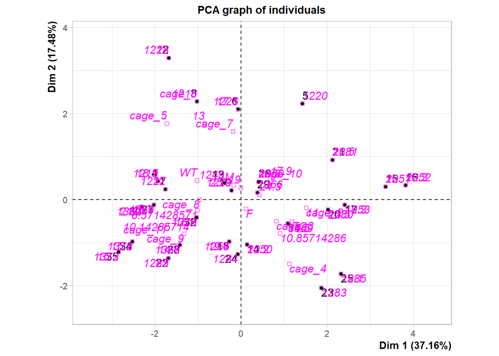

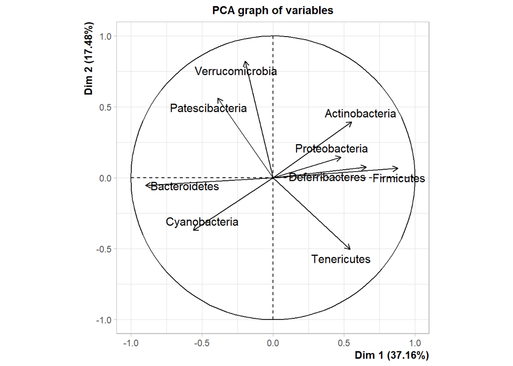

```r
Nouveau_TGWT<-tableau_fusionnée[-c(7:12),]
acp_phyla_Geno<-PCA(Nouveau_TGWT, graph=T, quali.sup = c(1:6))
```

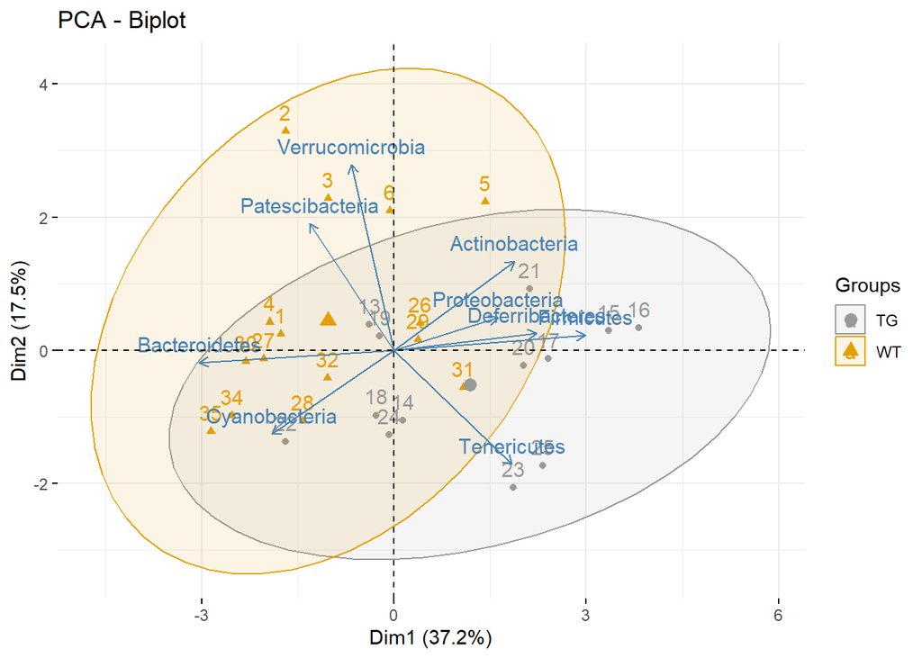

```r
fviz_pca_biplot (acp_phyla_Geno,
                 habillage=factor(Nouveau_TGWT$Geno),
     addEllipses=T,
     palette = c("#999999", "#E69F00"))
```

La différence de microbiotes intestinaux des souris transgéniques et sauvages serait quantitative. En effet, la majorité des phyla présents chez les sauvages sont également présents chez les souris transgénique.

Le séquençage du microbiote fécal de ces souris a été réalisé précédemment dans le laboratoire (autres souris, autre animalerie). L’analyse avait montré une abondance relative du phylum des Firmicutes plus abondante chez les souris transgéniques par rapport aux contrôles. Le rapport Firmicutes/Bacteroidetes (très souvent analysé dans la littérature) est également en faveur des transgéniques.

- *Retrouvez vous ce résultat ? Montrez et commentez*

Afin de savoir si le rapport irmicutes/Bacteroidetes est plus élevé chez les souris TG par rapport à celles sauvages comme indiqué dans la littérature, un calcul de ce rapport est effectué puis des tests statistiques sont réalisés afin de savoir s’il y aune différence significative.

```r
# Calcul des ratios des phyla chez les TG
firmicutes_bacteroidetes_ratio_TG = TG$Firmicutes/ TG$Bacteroidetes
#Renommer la colonne contenant le ratio des TG
head(firmicutes_bacteroidetes_ratio_TG)
```

```
## [1] 0.3564367 0.7631343 0.2506086 0.8253200 0.4716117 0.4781699
```

```r
print(firmicutes_bacteroidetes_ratio_TG)
```

```
##  [1] 0.3564367 0.7631343 0.2506086 0.8253200 0.4716117 0.4781699 0.5431929
##  [8] 0.3809994 1.2481197 0.9330947 0.7356033 0.4159079 0.4383741 0.8669184
## [15] 0.7239020 0.2885017 1.0402571 0.5521924 0.8468695
```

```r
WT <- subset(tableau_fusionnée, tableau_fusionnée$Geno=="WT")
# Calcul des ratios des phyla chez les WT
firmicutes_bacteroidetes_ratio_WT = WT$Firmicutes/ WT$Bacteroidetes
print(firmicutes_bacteroidetes_ratio_WT)
```

```
##  [1] 0.2555594 0.4330637 0.5655431 0.3243973 0.6078285 0.7178855 0.5032821
##  [8] 0.4325001 0.3634541 0.6196618 0.2699103 0.6272463 0.4721620 0.4205795
## [15] 0.3073733
```

```r
head(firmicutes_bacteroidetes_ratio_WT)
```

```
## [1] 0.2555594 0.4330637 0.5655431 0.3243973 0.6078285 0.7178855
```

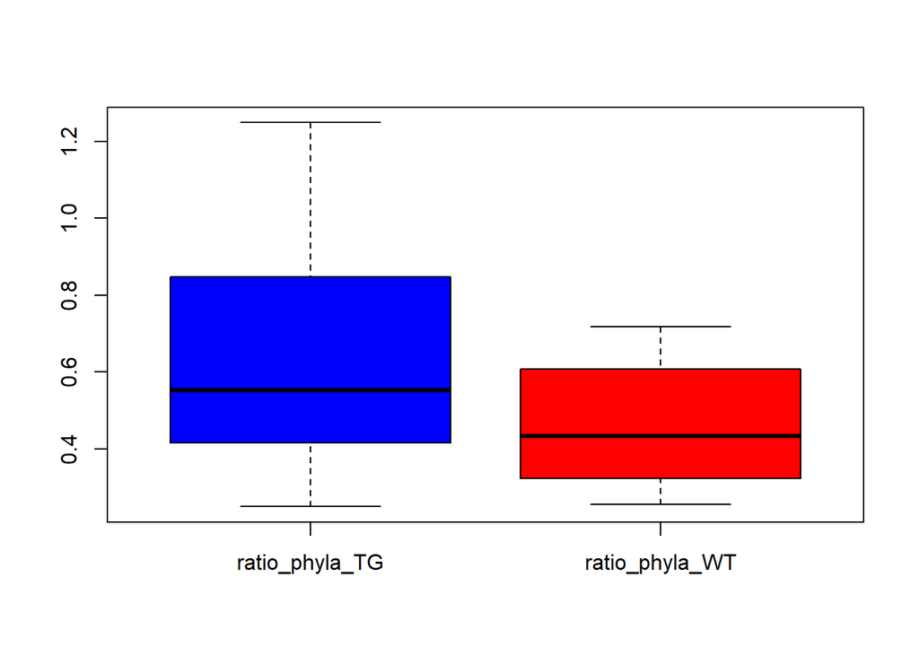

```r
#Fusion des deux colonnes des ratios des TG et des WT
ratio_phyla<-merge(firmicutes_bacteroidetes_ratio_TG, firmicutes_bacteroidetes_ratio_WT)

#Renommer les colonnes
names(ratio_phyla) <- c("ratio_phyla_TG", "ratio_phyla_WT")

boxplot(ratio_phyla, col=c("blue", "red"))
```

D’après le boxplot ci-dessus, le rapport médian Firmicutes/Bacteroidetes semble etre plus élevé chez les souris transgéniques par rapport à celles WT. Pour confimer cela, des tests statistiques sont réalisés.

1. *Normalité des données: Test de normalité de shapiro-wilk*

```r
#HO: Les données suivent une loi normale
#H1: Inverse
shapiro.test(ratio_phyla$ratio_phyla_TG)
```

```
##
##  Shapiro-Wilk normality test
##
## data:  ratio_phyla$ratio_phyla_TG
## W = 0.93719, p-value = 1.205e-09
```

```r
shapiro.test(ratio_phyla$ratio_phyla_WT)
```

```
##
##  Shapiro-Wilk normality test
##
## data:  ratio_phyla$ratio_phyla_WT
## W = 0.9368, p-value = 1.104e-09
```

Conclusion: Les données de ratio des phyla firmicutes/bacteroidetes ne suivent pas une loi normale (p-value<0,05 pour les TG et les WT).

2. *Test de comparaison des ratios médians des deux goupes de souris sauvages (WT) et transgéniques (TG): test de wilcoxon*

Comme les données ne suivent pas une loi normale, nous réaliserons un test de comparaison des médianes est effectué.

```r
#Ho : Les medianes des deux groupes sont égales
#H1: Les medianes ne sont pas égales
wilcox.test(ratio_phyla$ratio_phyla_TG, ratio_phyla$ratio_phyla_WT)
```

```
##
##  Wilcoxon rank sum test with continuity correction
##
## data:  ratio_phyla$ratio_phyla_TG and ratio_phyla$ratio_phyla_WT
## W = 55860, p-value = 8.558e-15
## alternative hypothesis: true location shift is not equal to 0
```

```r
#Calculs des poids moyens
summary(ratio_phyla$ratio_phyla_TG)
```

```
##    Min. 1st Qu.  Median    Mean 3rd Qu.    Max.
##  0.2506  0.4159  0.5522  0.6400  0.8469  1.2481
```

```r
summary(ratio_phyla$ratio_phyla_WT)
```

```
##    Min. 1st Qu.  Median    Mean 3rd Qu.    Max.
##  0.2556  0.3244  0.4331  0.4614  0.6078  0.7179
```